# Lab07

# Q5: Generating all pairwise plots may help somewhat. Can you make sense of the following code and resulting figure? What does it mean if a given point lies on the diagonal for a given plot?

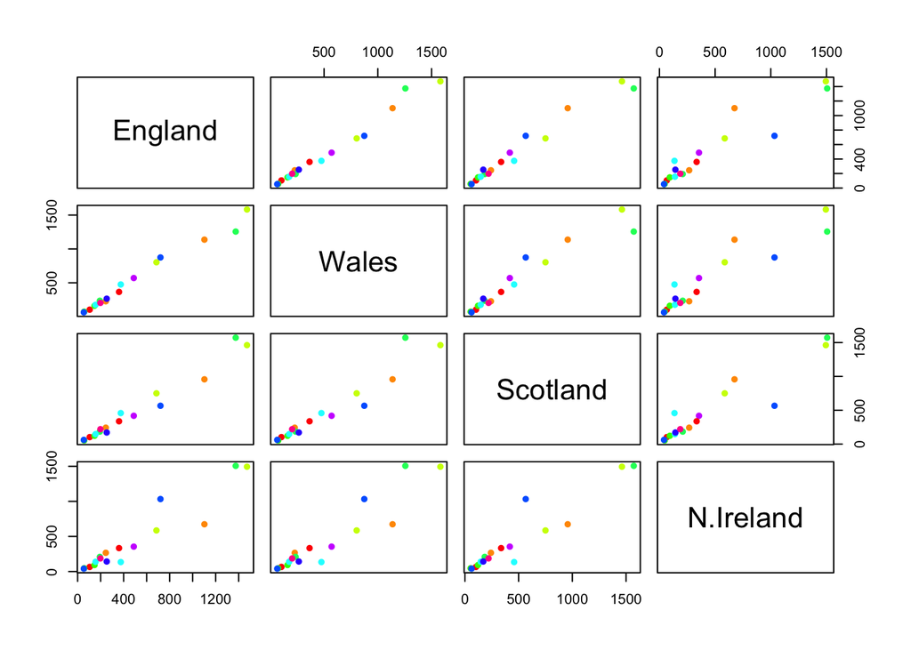

```r
pairs(x, col=rainbow(10), pch=16)
```

It seems like the graph would the comparison between the two countries that are either on its horizontal or vertical axis. If it is on the line, the data is similar between both of them. However, if the data leans more horizontal or vertical from the diagonal axis then it looks like it is more related towards that country it is leaning towards.

# Q6. What is the main differences between N. Ireland and the other countries of the UK in terms of this data-set?

The orange dot around the x=1100-1200 and the blue line at around x=700 (when looking at the graph of N.Ireland vs England)

# Use the prcomp() PCA function

```r
pca <- prcomp( t(x) )
summary(pca)
```

```
## Importance of components:
##                             PC1      PC2      PC3       PC4
## Standard deviation     324.1502 212.7478 73.87622 4.189e-14
## Proportion of Variance   0.6744   0.2905  0.03503 0.000e+00
## Cumulative Proportion    0.6744   0.9650  1.00000 1.000e+00
```

# Q7. Complete the code below to generate a plot of PC1 vs PC2. The second line adds text labels over the data points.

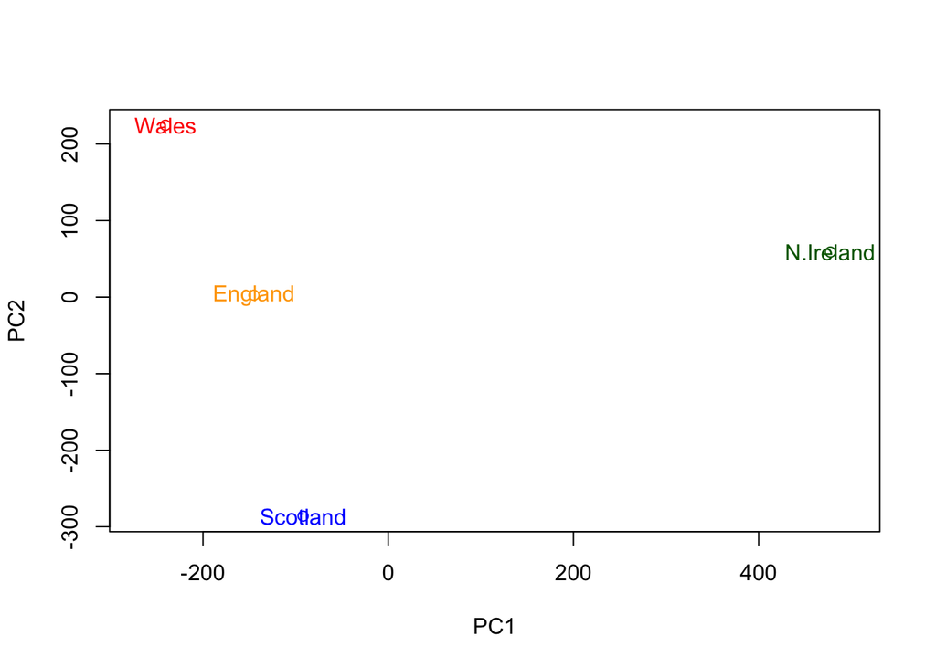

```r
# Plot PC1 vs PC2 ("PCA plot" or "Score plot")
plot(pca$x[,1], pca$x[,2], xlab="PC1", ylab="PC2", xlim=c(-270,500),col=c("orange","red","blue", "darkgreen"))
text(pca$x[,1], pca$x[,2], colnames(x),col=c("orange","red","blue", "darkgreen"))
```

```r
v <- round( pca$sdev^2/sum(pca$sdev^2) * 100 )
v
```

```
## [1] 67 29  4  0
```